# Credit Card Default Analysis and Prediction

Rajkumar Conjeevaram Mohan

29/04/2022

```r
data.orig <- read_xls(path='default of credit card clients.xls',
                      sheet='Data',  skip=1)
data <- data.frame(data.orig)
colnames(data) <- c('id', 'credit_limit', 'gender', 'education', 'marital', 'age', 'rs_sep', 'rs_aug', 'rs_july', 'rs_june', 'rs_may', 'rs_apr', 'bs_sep', 'bs_aug', 'bs_july', 'bs_june', 'bs_may', 'bs_apr', 'ap_sep', 'ap_aug', 'ap_july', 'ap_june', 'ap_may', 'ap_apr', 'default_r')
data <- data[data$marital!=0,]
# Marital status (1 = married; 2 = single; 3 = others)
data[data$marital == 2, 'marital'] <- 'Single'
data[data$marital == 1, 'marital'] <- 'Married'
data[data$marital == 3, 'marital'] <- 'Others'
marital.levels <- c("Single", "Married", "Others")
data$marital <- factor(data$marital, levels = marital.levels)

data[data$education >= 4 | data$education ==0, 'education'] <- 4
# Education (1 = graduate school; 2 = university; 3 = high school; 4 = others)
data[data$education==1, 'education'] <- 'Graduate School'
data[data$education==2, 'education'] <- 'University'
data[data$education==3, 'education'] <- 'High School'
data[data$education==4, 'education'] <- 'Others'
education.levels <- c("Others", "High School", "Graduate School", "University")
data$education <- factor(data$education, levels=education.levels)

# Gender (1 = male; 2 = female)
data[data$gender==1, 'gender'] <- 'Male'
data[data$gender==2, 'gender'] <- 'Female'
gender_levels <- c("Male", "Female")
data$gender <- factor(data$gender, levels=gender_levels)

data$rs_sep <- factor(data$rs_sep)
data$rs_aug <- factor(data$rs_aug)
data$rs_july <- factor(data$rs_july)
data$rs_june <- factor(data$rs_june)
data$rs_may <- factor(data$rs_may)
data$rs_apr <- factor(data$rs_apr)
data[data$default_r==1, 'default_r'] <- 'Yes'
data[data$default_r==0, 'default_r'] <- 'No'
default_levels <- c("No", "Yes")
data$default_r <- factor(data$default_r, levels=default_levels)
```

# 1 Introduction

Since the beginning in 1990, Taiwan banks, in order to improve their financial market and expand their profit, started lending money to real estate businesses. When real estate businesses started saturating, they decided to focus on credit card businesses and started issuing cards to many individuals regardless of their repayment capacity. One of their primary targets was school going young students, who were easily exploited given their lack of knowledge in finance and other risks involved. As per Taiwanese Department of Health report, the suicide rate was increased to $22.9%$ in 2006 compared to 2005 mainly over debt concerns. Many lost their homes, some resorted to illegal engagement for repayment, all caused by their inability to repay the debt. In 2006, the debt from credit card and cash card reached about $\$268$ billion USD and caused a financial crisis that blew the consumer finance confidence. In order to control the situation and prevent cards from being further issued to ineligible consumers, Financial Department of Taiwanese government issued regulation notice to banks increasing the income and other criteria to apply for credit card.

Several financial firms around the globe are taking stringent measures to prevent credit card default by using credit history and other payment patterns using Machine Learning models that help in predicting a potential client who possibly will default on their bill. In order to further understand what factors constitute to default behavior and by what factor the chances to default increase, I wish to use Exploratory Data Analysis along with hypothesis test to answer some of the preconceived opinions, and use ML models such as Logistic Regression, Decision Tree, Random Forest, Extremely Randomized Forest for predicting client who may default.

# 2 SMART Questions

1. Are people with better educational qualification exhibit better repayment pattern?
2. Is there a specific gender that is more prone to making default?
3. Are married people more likely to default as to the increased financial requirement for them?
4. What measures can be taken to mitigate the risks of insolvency?

# 3 Data

## 3.1 Overview

```r
str(data)
```

[output not shown]

## 3.2 Description

**Explanation for notable variables**

| Variable | Description |
| --- | --- |
| rs | repayment status |
| bs | bill statement |
| ap | amount paid |
| default_r | Whether the client has defaulted (response variable) |

**Repayment Status Level Description**

| Level | Description |
| --- | --- |
| -2 | No consumption of credit |
| -1 | Paid promptly |
| 0 | Use of revolving credit |
| 1..8 | Represents the number of months due |
| 9 | Due for 9 months or over |

## 3.3 Head and Tail

```r
rmarkdown::paged_table(head(data, 5))
```

|  | id | credit_limit | gender | education | marital | age | rs_sep | rs_aug | rs_july | rs_june | rs_may | rs_apr | bs_sep | bs_aug | bs_july | bs_june | bs_may | bs_apr | ap_sep | ap_aug | ap_july | ap_june | ap_may | ap_apr | default_r |
| --- | --- | --- | --- | --- | --- | --- | --- | --- | --- | --- | --- | --- | --- | --- | --- | --- | --- | --- | --- | --- | --- | --- | --- | --- | --- |
| 1 | 1 | 20000 | Female | University | Married | 24 | 2 | 2 | -1 | -1 | -2 | -2 | 3913 | 3102 | 689 | 0 | 0 | 0 | 0 | 689 | 0 | 0 | 0 | 0 | Yes |
| 2 | 2 | 120000 | Female | University | Single | 26 | -1 | 2 | 0 | 0 | 0 | 2 | 2682 | 1725 | 2682 | 3272 | 3455 | 3261 | 0 | 1000 | 1000 | 1000 | 0 | 2000 | Yes |
| 3 | 3 | 90000 | Female | University | Single | 34 | 0 | 0 | 0 | 0 | 0 | 0 | 29239 | 14027 | 13559 | 14331 | 14948 | 15549 | 1518 | 1500 | 1000 | 1000 | 1000 | 5000 | No |
| 4 | 4 | 50000 | Female | University | Married | 37 | 0 | 0 | 0 | 0 | 0 | 0 | 46990 | 48233 | 49291 | 28314 | 28959 | 29547 | 2000 | 2019 | 1200 | 1100 | 1069 | 1000 | No |
| 5 | 5 | 50000 | Male | University | Married | 57 | -1 | 0 | -1 | 0 | 0 | 0 | 8617 | 5670 | 35835 | 20940 | 19146 | 19131 | 2000 | 36681 | 10000 | 9000 | 689 | 679 | No |

```r
rmarkdown::paged_table(tail(data, 5))
```

|  | id | credit_limit | gender | education | marital | age | rs_sep | rs_aug | rs_july | rs_june | rs_may | rs_apr | bs_sep | bs_aug | bs_july | bs_june | bs_may | bs_apr | ap_sep | ap_aug | ap_july | ap_june | ap_may | ap_apr | default_r |
| --- | --- | --- | --- | --- | --- | --- | --- | --- | --- | --- | --- | --- | --- | --- | --- | --- | --- | --- | --- | --- | --- | --- | --- | --- | --- |
| 29996 | 29996 | 220000 | Male | High School | Married | 39 | 0 | 0 | 0 | 0 | 0 | 0 | 188948 | 192815 | 208365 | 88004 | 31237 | 15980 | 8500 | 20000 | 5003 | 3047 | 5000 | 1000 | No |
| 29997 | 29997 | 150000 | Male | High School | Single | 43 | -1 | -1 | -1 | -1 | 0 | 0 | 1683 | 1828 | 3502 | 8979 | 5190 | 0 | 1837 | 3526 | 8998 | 129 | 0 | 0 | No |
| 29998 | 29998 | 30000 | Male | University | Single | 37 | 4 | 3 | 2 | -1 | 0 | 0 | 3565 | 3356 | 2758 | 20878 | 20582 | 19357 | 0 | 0 | 22000 | 4200 | 2000 | 3100 | Yes |
| 29999 | 29999 | 80000 | Male | High School | Married | 41 | 1 | -1 | 0 | 0 | 0 | -1 | -1645 | 78379 | 76304 | 52774 | 11855 | 48944 | 85900 | 3409 | 1178 | 1926 | 52964 | 1804 | Yes |
| 30000 | 30000 | 50000 | Male | University | Married | 46 | 0 | 0 | 0 | 0 | 0 | 0 | 47929 | 48905 | 49764 | 36535 | 32428 | 15313 | 2078 | 1800 | 1430 | 1000 | 1000 | 1000 | Yes |

## 3.4 Distribution of Imbalanced data

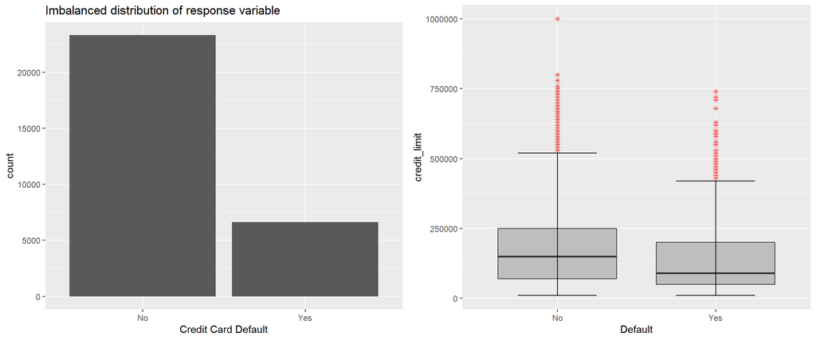

```r
hist.default <- ggplot(data, aes(x=default_r)) +
                geom_bar() +
                xlab('Credit Card Default') +
                ggtitle('Imbalanced distribution of response variable')
bxpt.default <- ggplot(data, aes(x=default_r, y=credit_limit)) +
                geom_boxplot(outlier.color = 'red', outlier.shape = 8, fill='gray') +
                stat_boxplot(geom='errorbar', width=0.5) + xlab('Default')

grid.arrange(hist.default, bxpt.default, nrow=1)
```

### 3.4.1 Understanding of SMOTE

From my understanding, there are a few ways to handle imbalanced dataset and some of them include oversampling minority class data, data augmentation, etc,. One of the most common techniques in oversampling minority class is SMOTE (Synthetic Minority Oversampling Technique). SMOTE works by first fitting a KNN model (compute pair-wise distance matrix), then randomly select a sample of minority class and pick the `k` neighbors. When an adjacency matrix is created using the `k` neighbors, we randomly sample features between the range of selected pair of neighbors. This way, as we increase the sampling size, we end up with more samples in minority class.

```r
data <- SMOTE(default_r~., data=data, perc.over=280)
```

## 3.5 Distribution post SMOTE

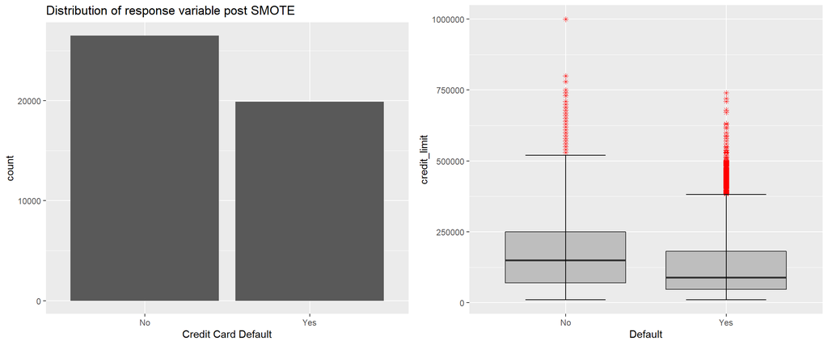

```r
hist.default <- ggplot(data, aes(x=default_r)) +
                geom_bar() +
                xlab('Credit Card Default') +
                ggtitle('Distribution of response variable post SMOTE')
bxpt.default <- ggplot(data, aes(x=default_r, y=credit_limit)) +
                geom_boxplot(outlier.color = 'red', outlier.shape = 8, fill='gray') +
                stat_boxplot(geom='errorbar', width=0.5) + xlab('Default')

grid.arrange(hist.default, bxpt.default, nrow=1)
```

```r
# H0: Credit limit of those who default is less than that of who pay promptly
# H1: Credit limit of those who default is higher than that of who pay promptly
ttest.credit_limit <- t.test(data[data$default_r=="Yes", 'credit_limit'],
                             mu=mean(data[data$default_r=="No", 'credit_limit']),
                             alternative='greater')
ttest.credit_limit
```

[output not shown]

## 3.6 Age and Default

```r
hist.age <- ggplot(data, aes(x=age)) +
            geom_histogram(color='white') +
            geom_vline(xintercept=mean(data$age), color='blue', lwd=1.6) +
            geom_vline(xintercept=median(data$age), color='red', lwd=1.6,
                       linetype='dashed')
            ggtitle('Age distribution')
```

```
## $title
## [1] "Age distribution"
##
## attr(,"class")
## [1] "labels"
```

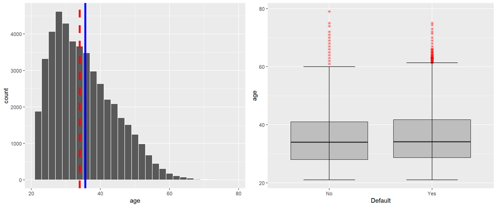

```r
bxpt.age <- ggplot(data, aes(x=default_r, y=age)) +
            geom_boxplot(outlier.color = 'red', outlier.shape = 8,
                         fill='gray') +
            stat_boxplot(geom='errorbar', width=0.5) + xlab('Default')

grid.arrange(hist.age, bxpt.age, nrow=1)
```

```r
# Confidence inteveral for those who default
ttest_1s_default_age <- t.test(data[data$default_r=="Yes", "age"])

# Confidence interval for those who do not default
ttest_1s_ndefault_age <- t.test(data[data$default_r=="No", "age"])

ttest.age_default <- t.test(data[data$default_r=="Yes", 'age'],
                            data[data$default_r=="No", 'age'])
ttest.age_default
```

```
##
##  Welch Two Sample t-test
##
## data:  data[data$default_r == "Yes", "age"] and data[data$default_r == "No", "age"]
## t = 4, df = 43188, p-value = 3e-05
## alternative hypothesis: true difference in means is not equal to 0
## 95 percent confidence interval:
##  0.185 0.517
## sample estimates:
## mean of x mean of y
##      35.8      35.4
```

The `t.test` on age between those who defaulted on their credit card bills and those who did not, returned a `p.value` of 3.317^{-5}. In simple words, the difference in age between the two subgroups is not equal to 0.

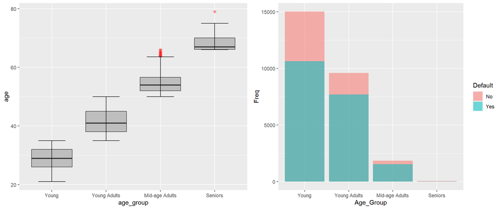

```r
# Group them so we can have an overall understanding of at which age the default
# happens
data$age_group = 0
data[data$age <= 35, "age_group"] <- "Young"
data[data$age >35 & data$age <= 50, "age_group"] <- "Young Adults"
data[data$age >50 & data$age < 66, "age_group"] <- "Mid-age Adults"
data[data$age >= 66, "age_group"] <- "Seniors"

data$age_group <- factor(data$age_group, levels=c("Young", "Young Adults",
                                                  "Mid-age Adults", "Seniors"))

age_group_default_cont <- table(data$default_r, data$age_group)
chisq.age_default <- chisq.test(age_group_default_cont)

age_group_default_cont <- data.frame(age_group_default_cont)
colnames(age_group_default_cont) <- c("Default", "Age_Group", "Freq")


bxpt.age_group_default <- ggplot(data, aes(x=age_group, y=age)) +
                          geom_boxplot(outlier.color='red', outlier.shape=8,
                                       fill='gray') +
                          stat_boxplot(geom='errorbar', width=0.5)

bar.age_group_default <- ggplot(age_group_default_cont, aes(x=Age_Group, y=Freq, fill=Default)) +
                         geom_bar(stat='identity', position='identity', alpha=0.55)

grid.arrange(bxpt.age_group_default, bar.age_group_default, nrow=1)
```

```r
# tmp_data <- data %>% group_by(age_group) %>% summarise(default_count = count(default_r))

chisq.age_default
```

```
##
##  Pearson's Chi-squared test
##
## data:  age_group_default_cont
## X-squared = 56, df = 3, p-value = 3e-12
```

I have grouped age into different categories so that it is possible to understand who typically default and their individual circumstances. As it can be seen from the rightmost plot, it would be the young people who default the most, and those who are in mid-age or seniors have relatively less default frequency. I believe it would throw more light if we could visualize the educational qualification of Young, other age groups. Perhaps we can observe the connection of default with education.

## 3.7 Education and Default

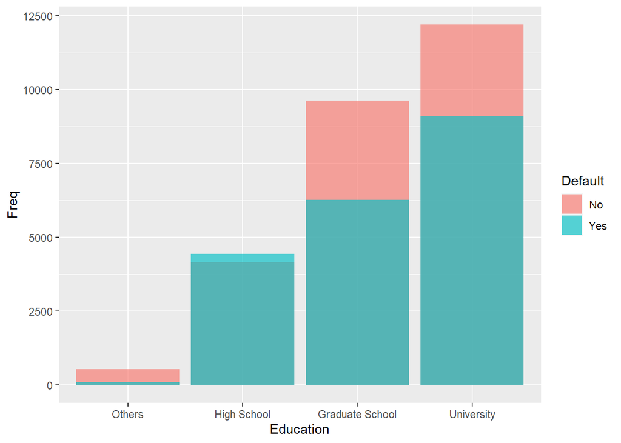

```r
educ_default_cont <- table(data$default, data$education)
chisq.educ_default <- chisq.test(educ_default_cont)

educ_default_cont <- data.frame(educ_default_cont)
colnames(educ_default_cont) <- c("Default", "Education", "Freq")

hist.educ <- ggplot(educ_default_cont, aes(x=Education, y=Freq, fill=Default)) +
             geom_bar(stat='identity', position='identity', alpha=0.65)

hist.educ
```

```r
chisq.educ_default
```

```
##
##  Pearson's Chi-squared test
##
## data:  educ_default_cont
## X-squared = 555, df = 3, p-value <2e-16
```

It was my initial understanding that it would be school going young students who were the primary target for the credit card business, but the results show those with University qualification default the most. Although it makes sense that the financial requirement of students at the University level may be inclined, the conclusion I would like draw from this is that the initial news report mentioned the banks targeted school students as they were apparently the ones who weren’t applying for credit cards and I believe, it was a conscious move to expand their business and does not necessarily mean they were the ones who most default.

### 3.7.1 Education and Amount Paid in September

```r
educ_ap_sep <- aov(ap_sep~education, data=data)
summary(educ_ap_sep)
```

```
##                Df   Sum Sq  Mean Sq F value Pr(>F)
## education       3 2.99e+10 9.96e+09    46.5 <2e-16 ***
## Residuals   46413 9.93e+12 2.14e+08
## ---
## Signif. codes:  0 '***' 0.001 '**' 0.01 '*' 0.05 '.' 0.1 ' ' 1
```

### 3.7.2 Education and Amount Paid in July

```r
educ_ap_july <- aov(ap_july~education, data=data)
summary(educ_ap_july)
```

```
##                Df   Sum Sq  Mean Sq F value Pr(>F)
## education       3 3.84e+10 1.28e+10    49.1 <2e-16 ***
## Residuals   46413 1.21e+13 2.61e+08
## ---
## Signif. codes:  0 '***' 0.001 '**' 0.01 '*' 0.05 '.' 0.1 ' ' 1
```

Amount paid by people with different qualification differs on average, as per the ANOVA results. In other words we choose Alternative hypothesis that the mean of amount paid by different subgroups are not the same.

## 3.8 Marital and Default

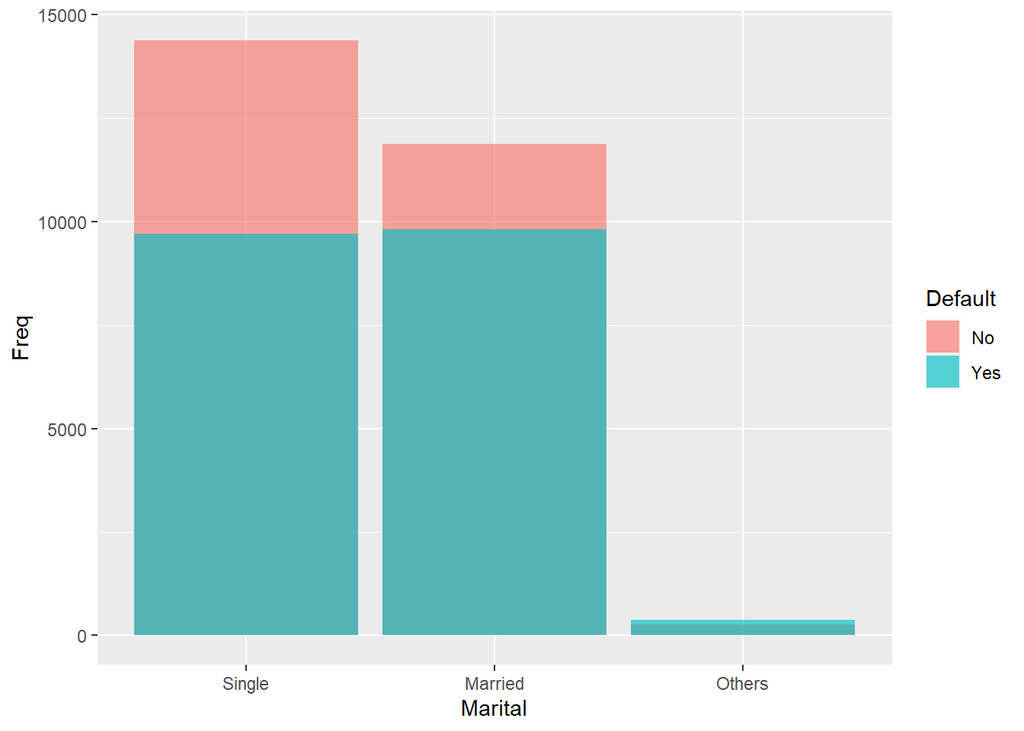

```r
# Marital status (1 = married; 2 = single; 3 = others)
# Remove rows that have marital 0 since it is not given any meaning

marital_default_cont <- table(data$default_r, data$marital)
chisq.marital_default <- chisq.test(marital_default_cont)

marital_default_cont <- data.frame(marital_default_cont)
colnames(marital_default_cont) <- c("Default", "Marital", "Freq")

ggplot(marital_default_cont, aes(x=Marital, y=Freq, fill=Default)) +
geom_bar(stat='identity', position='identity', alpha=0.65) + xlab('Marital')
```

```r
# marital_default_cont

chisq.marital_default
```

```
##
##  Pearson's Chi-squared test
##
## data:  marital_default_cont
## X-squared = 180, df = 2, p-value <2e-16
```

I tried ignoring the `Others` column from including in contingency table and re-running the chi-squared test and it still produced a `p.value` of 9.189^{-40} pointing to the fact that two groups `Single` and `Married` do have an effect on `default`.

## 3.9 Marital and Amount paid in September

```r
marital_ap_sep <- aov(ap_sep~marital, data=data)
summary(marital_ap_sep)
```

```
##                Df   Sum Sq  Mean Sq F value Pr(>F)
## marital         2 1.88e+09 9.38e+08    4.37  0.013 *
## Residuals   46414 9.95e+12 2.14e+08
## ---
## Signif. codes:  0 '***' 0.001 '**' 0.01 '*' 0.05 '.' 0.1 ' ' 1
```

## 3.10 Marital and Amount paid in July

```r
marital_ap_july <- aov(ap_july~marital, data=data)
summary(marital_ap_july)
```

```
##                Df   Sum Sq  Mean Sq F value Pr(>F)
## marital         2 4.14e+08 2.07e+08    0.79   0.45
## Residuals   46414 1.21e+13 2.62e+08
```

## 3.11 Gender and default

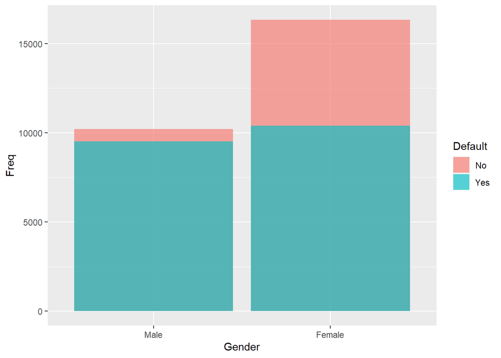

```r
gender_default_cont <- table(data$gender, data$default_r)
chisq.gender_default <- chisq.test(gender_default_cont)
gender_default_cont <- data.frame(gender_default_cont)
colnames(gender_default_cont) <- c("Gender", "Default", "Freq")

hist.gender_default <- ggplot(gender_default_cont, aes(x=Gender, y=Freq, fill=Default)) +
                        geom_bar(stat='identity', position='identity', alpha=0.65)
hist.gender_default
```

```r
chisq.gender_default
```

```
##
##  Pearson's Chi-squared test with Yates' continuity correction
##
## data:  gender_default_cont
## X-squared = 407, df = 1, p-value <2e-16
```

From the above plot, it can be understood that there are more number of Females who default compared to Males. Why is this the case ? A possible cause could be a bias in education. Let’s understand this further. Also there are more number of Females who have not defaulted on their bill.

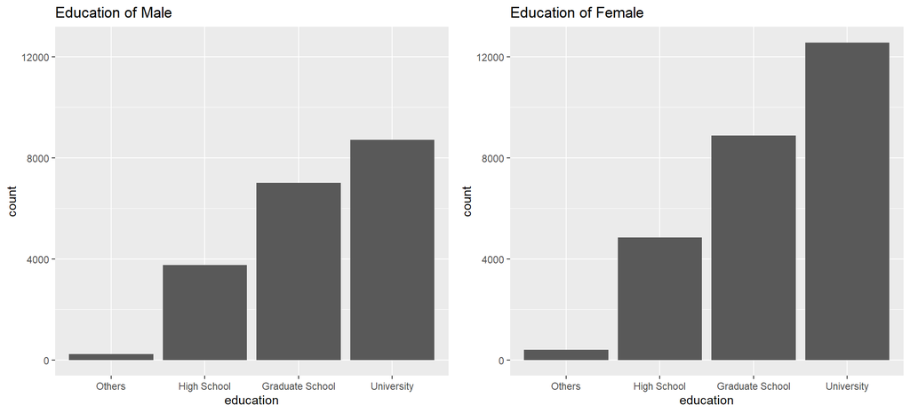

```r
gender_educ_summary <- data %>%
                       group_by(gender) %>%
                       summarize(University = sum(education=='University'),
                                 GraduateSchool = sum(education=='Graduate School'),
                                 HighSchool = sum(education=='High School'),
                                 Others = sum(education=='Others'))

max_ylim <- max(data.frame(gender_educ_summary)[2:5])

hist.male_educ <- ggplot(data[data$gender=='Male',], aes(x=education)) +
                  geom_bar() + ggtitle('Education of Male') +
                  ylim(c(0, max_ylim))
hist.female_educ <- ggplot(data[data$gender=='Female',], aes(x=education)) +
                    geom_bar() + ggtitle('Education of Female') +
                    ylim(c(0, max_ylim))

grid.arrange(hist.male_educ, hist.female_educ, nrow=1)
```

The results were surprising as it was believed there was gap in education in Females that led to more defaulting, but from the plot it appears they are more qualified than Males. Now I believe I can make a connection of this finding to a plot under `Education and Default` that showed University level qualification holders are the ones with more financial demands. In other words, they are the ones who most typically default. Hence the conclusion is, since Females are the ones with most University level qualification, they often face difficulties in repaying their credit card bill.

## 3.12 Repayment Status Pattern

The data comes with past repayment status between April to September.

A quick legend of the numbers on the x-axis for the plot below:

[output not shown]

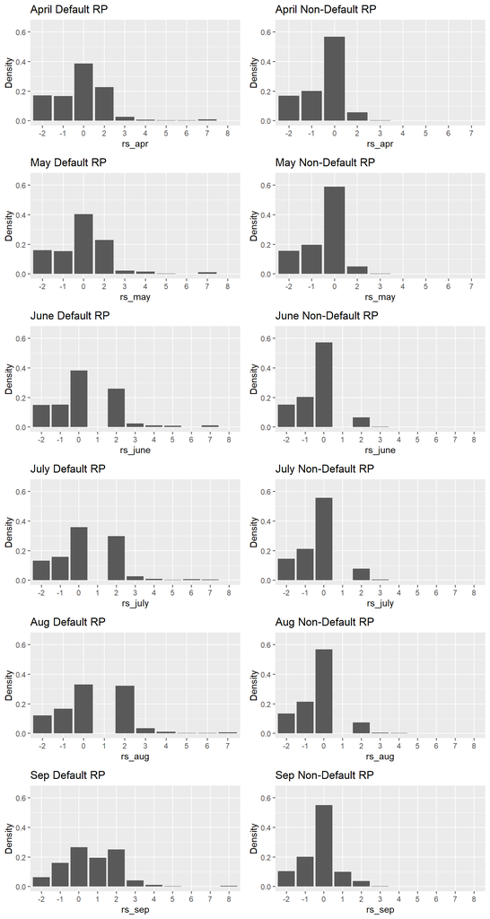

```r
sep_df <- ggplot(data[data$default_r=='Yes',], aes(x=rs_sep, y=)) +
          geom_bar(aes(y = (..count..)/sum(..count..))) + ylab('Density') +
          ylim(c(0, 0.65)) +
           ggtitle('Sep Default RP')

sep_ndf <- ggplot(data[data$default_r=='No',], aes(x=rs_sep)) + ylab('Density') +
           geom_bar(aes(y = (..count..)/sum(..count..))) +
            ylim(c(0, 0.65)) +
            ggtitle('Sep Non-Default RP')

aug_df <- ggplot(data[data$default_r=='Yes',], aes(x=rs_aug)) + ylab('Density') +
           geom_bar(aes(y = (..count..)/sum(..count..))) +
           ylim(c(0, 0.65)) + ggtitle('Aug Default RP')

aug_ndf <- ggplot(data[data$default_r=='No',], aes(x=rs_aug)) + ylab('Density') +
           geom_bar(aes(y = (..count..)/sum(..count..))) +
           ylim(c(0, 0.65)) + ggtitle('Aug Non-Default RP')

july_df <- ggplot(data[data$default_r=='Yes',], aes(x=rs_july)) + ylab('Density') +
           geom_bar(aes(y = (..count..)/sum(..count..))) +
           ylim(c(0, 0.65)) + ggtitle('July Default RP')

july_ndf <- ggplot(data[data$default_r=='No',], aes(x=rs_july)) + ylab('Density') +
            geom_bar(aes(y = (..count..)/sum(..count..))) +
           ylim(c(0, 0.65)) +  ggtitle('July Non-Default RP')

june_df <- ggplot(data[data$default_r=='Yes',], aes(x=rs_june)) + ylab('Density') +
           geom_bar(aes(y = (..count..)/sum(..count..))) +
           ylim(c(0, 0.65)) + ggtitle('June Default RP')

june_ndf <- ggplot(data[data$default_r=='No',], aes(x=rs_june)) + ylab('Density') +
            geom_bar(aes(y = (..count..)/sum(..count..))) +
            ylim(c(0, 0.65)) + ggtitle('June Non-Default RP')

may_df <- ggplot(data[data$default_r=='Yes',], aes(x=rs_may)) + ylab('Density') +
          geom_bar(aes(y = (..count..)/sum(..count..))) +
          ylim(c(0, 0.65)) + ggtitle('May Default RP')

may_ndf <- ggplot(data[data$default_r=='No',], aes(x=rs_may)) + ylab('Density') +
           geom_bar(aes(y = (..count..)/sum(..count..))) +
           ylim(c(0, 0.65)) + ggtitle('May Non-Default RP')

april_df <- ggplot(data[data$default_r=='Yes',], aes(x=rs_apr)) + ylab('Density') +
            geom_bar(aes(y = (..count..)/sum(..count..))) +
            ylim(c(0, 0.65)) + ggtitle('April Default RP')

april_ndf <- ggplot(data[data$default_r=='No',], aes(x=rs_apr)) + ylab('Density') +
             geom_bar(aes(y = (..count..)/sum(..count..))) +
             ylim(c(0, 0.65)) + ggtitle('April Non-Default RP')

grid.arrange(april_df, april_ndf, may_df, may_ndf, june_df, june_ndf,
             july_df, july_ndf, aug_df, aug_ndf, sep_df, sep_ndf, nrow=6, ncol=2 )
```

As it can be seen from the bunch of plots above, those who default **always** exhibit late payment or dues compared to those who do not. Observing the repayment status plot of those who do not default, it can be seen that 0 and -1 have higher frequencies compared to that of defaulters. This is one of the most critical information that banks can use to gauge their repayment capacity before deciding on their credit limit.

## 3.13 Summary of bills, payments and dues by age group

```r
library(dplyr)
ag_due_summary <-  data %>%
                   dplyr::group_by(age_group) %>%
                   dplyr::summarize(total_bill = mean(bs_sep + bs_aug + bs_july + bs_june + bs_may + bs_apr),
                                    total_paid = mean(ap_sep + ap_aug + ap_july + ap_june + ap_may + ap_apr),
                                    credit_limit = mean(credit_limit))

ag_due_summary <- data.frame(ag_due_summary)
ag_due_summary$due <- ag_due_summary$total_bill - ag_due_summary$total_paid
ag_due_summary$due_percent <- (ag_due_summary$due/ag_due_summary$credit_limit) * 100

rmarkdown::paged_table(ag_due_summary)
```

| age_group | total_bill | total_paid | credit_limit | due | due_percent |
| --- | --- | --- | --- | --- | --- |
| Young | 246618 | 25969 | 143316 | 220649 | 154 |
| Young Adults | 273768 | 30349 | 175228 | 243419 | 139 |
| Mid-age Adults | 253098 | 24468 | 148109 | 228630 | 154 |
| Seniors | 605451 | 41610 | 222895 | 563841 | 253 |

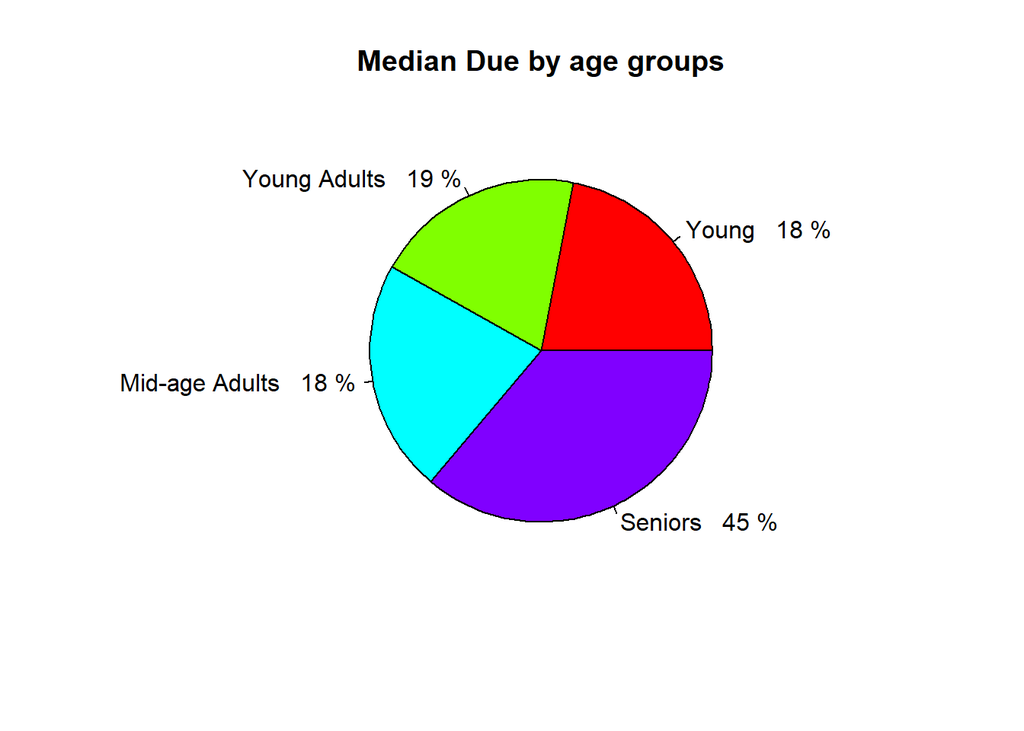

```r
due_norm <- round((ag_due_summary$due/sum(ag_due_summary$due)), 2)*100

med_due <- round(ag_due_summary$due_percent)
age_labels <- ag_due_summary$age_group
lbls <- paste(age_labels, ' ', due_norm, '%')
pie(med_due, labels=lbls, col=rainbow(length(lbls)), main="Median Due by age groups")
```

```r
getproportion <- function(x)
{
  ul <- unique(x)
  count <- NULL
  for(e in ul) # Hoping it produces in the same order as stored in ul
  {
    count <- c(count, sum(x==e))
  }
  count <- (count/sum(count)) * 100
  return(count)
  # m_c <- max(count, na.rm=T)
  # m_i <- which(count == m_c)
  # return(ul[m_i])
}
```

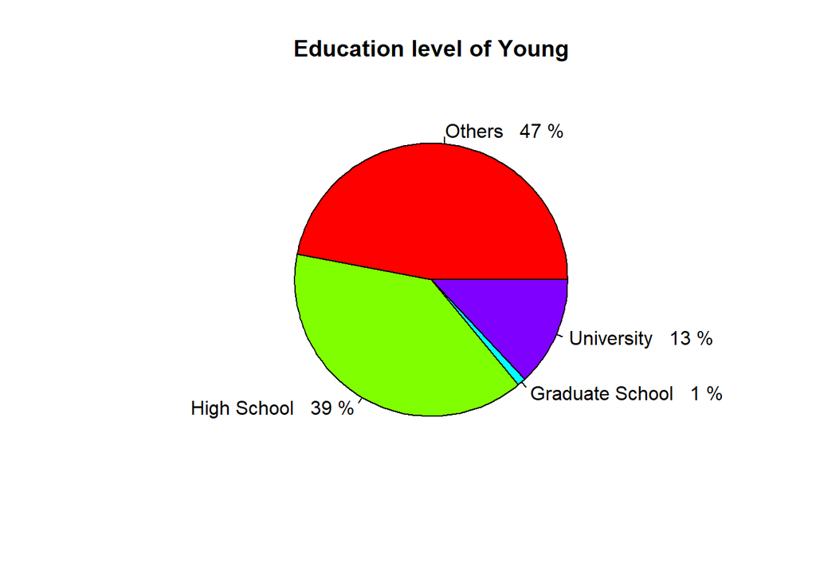

```r
education.young <- getproportion(data[data$age_group=='Young', 'education'])
education.young_adults <- getproportion(data[data$age_group=='Young Adults', 'education'])
education.midage_adults <- getproportion(data[data$age_group=='Mid-age Adults', 'education'])
education.seniors <- getproportion(data[data$age_group=='Seniors', 'education'])

young.educ_perc <- round(education.young)
young_adults.educ_perc <- round(education.young_adults)
midage_adults.educ_perc <- round(education.midage_adults)
seniors.educ_perc <- round(education.seniors)

# Young
lbls <- paste(education.levels, ' ', young.educ_perc, '%')
pie(young.educ_perc, labels=lbls, col=rainbow(length(lbls)), main="Education level of Young")
```

[figure not shown]

```r
# Young Adults
lbls <- paste(education.levels, ' ', young_adults.educ_perc, '%')
pie(young.educ_perc, labels=lbls, col=rainbow(length(lbls)), main="Education level of Young Adults")
```

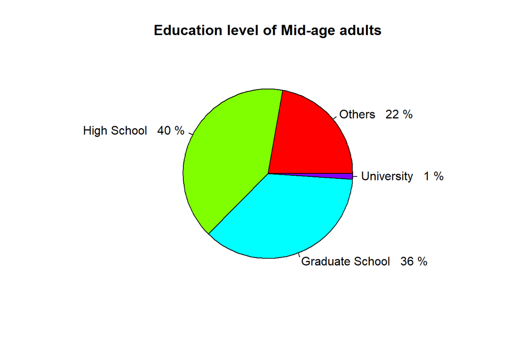

```r
# Mid-age Adults
lbls <- paste(education.levels, ' ', midage_adults.educ_perc, '%')
pie(midage_adults.educ_perc, labels=lbls, col=rainbow(length(lbls)), main="Education level of Mid-age adults")
```

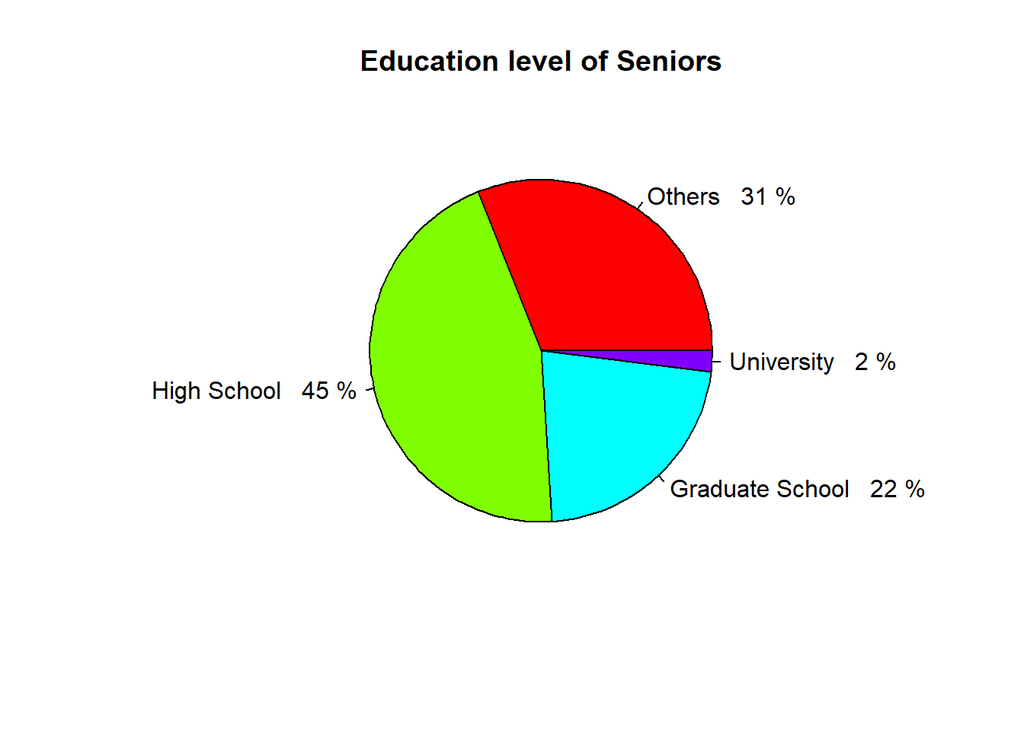

```r
# Seniors
lbls <- paste(education.levels, ' ', seniors.educ_perc, '%')
pie(seniors.educ_perc, labels=lbls, col=rainbow(length(lbls)), main="Education level of Seniors")
```

# 4 Modeling

## 4.1 Spearman Correlation plot

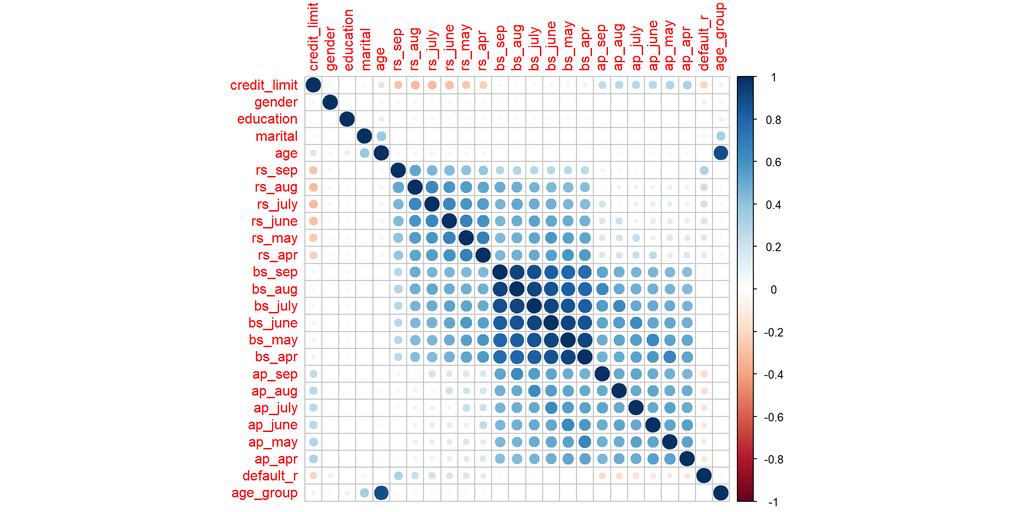

```r
data_f <- data
data_f$gender <- rank(data_f$gender)
data_f$education <- rank(data_f$education)
data_f$marital <- rank(data_f$marital)
data_f$age <- rank(data_f$age)

data_f$rs_sep <- rank(data_f$rs_sep)
data_f$rs_aug <- rank(data_f$rs_aug)
data_f$rs_july <- rank(data_f$rs_july)
data_f$rs_june <- rank(data_f$rs_june)
data_f$rs_may <- rank(data_f$rs_may)
data_f$rs_apr <- rank(data_f$rs_apr)

data_f$default_r <- rank(data_f$default_r)
data_f$age_group <- rank(data_f$age_group)

corrplot::corrplot(cor(data_f[, -1], method='spearman'), method='circle')
```

## 4.2 Full model using Generalised Linear Model

### 4.2.1 1st Attempt

This model was built with all data since I wanted an unbiased estimate of cofficients to understand by what factor the log(odds-ratio) is affected.

```r
full_model <- glm('default_r~.-id-age_group', data=data, family='binomial')
# full_model
summary(full_model)
```

```
##
## Call:
## glm(formula = "default_r~.-id-age_group", family = "binomial",
##     data = data)
##
## Deviance Residuals:
##    Min      1Q  Median      3Q     Max
## -3.759  -0.784  -0.517   0.852   4.293
##
## Coefficients:
##                           Estimate Std. Error z value Pr(>|z|)
## (Intercept)              -1.15e+00   1.43e-01   -8.09  5.8e-16 ***
## credit_limit             -1.93e-06   1.23e-07  -15.69  < 2e-16 ***
## genderFemale             -3.45e-01   2.28e-02  -15.14  < 2e-16 ***
## educationHigh School      1.28e+00   1.29e-01    9.90  < 2e-16 ***
## educationGraduate School  1.10e+00   1.28e-01    8.56  < 2e-16 ***
## educationUniversity       1.09e+00   1.28e-01    8.51  < 2e-16 ***
## maritalMarried            1.83e-01   2.42e-02    7.55  4.4e-14 ***
## maritalOthers             6.45e-01   9.43e-02    6.84  7.8e-12 ***
## age                       2.73e-03   1.37e-03    1.99  0.04618 *
## rs_sep-1                  4.38e-01   5.90e-02    7.42  1.2e-13 ***
## rs_sep0                  -1.91e-02   6.03e-02   -0.32  0.75127
## rs_sep1                   6.23e-01   5.23e-02   11.91  < 2e-16 ***
## rs_sep2                   1.81e+00   6.53e-02   27.76  < 2e-16 ***
## rs_sep3                   1.72e+00   1.23e-01   14.01  < 2e-16 ***
## rs_sep4                   1.54e+00   2.14e-01    7.23  5.0e-13 ***
## rs_sep5                   1.37e+00   3.89e-01    3.52  0.00042 ***
## rs_sep6                  -1.14e-01   5.15e-01   -0.22  0.82418
## rs_sep7                   2.70e+00   1.14e+00    2.38  0.01740 *
## rs_sep8                   1.10e+00   4.08e-01    2.69  0.00709 **
## rs_aug-1                 -1.57e-01   5.51e-02   -2.85  0.00437 **
## rs_aug0                  -3.55e-01   5.95e-02   -5.96  2.5e-09 ***
## rs_aug1                  -1.64e-01   3.79e-01   -0.43  0.66430
## rs_aug2                   3.61e-01   5.77e-02    6.25  4.2e-10 ***
## rs_aug3                   5.64e-01   1.19e-01    4.76  1.9e-06 ***
## rs_aug4                  -1.81e-01   1.86e-01   -0.97  0.33128
## rs_aug5                   2.20e-01   4.10e-01    0.54  0.59050
## rs_aug6                   2.39e+00   1.09e+00    2.19  0.02865 *
## rs_aug7                   8.87e-01   3.87e-01    2.29  0.02208 *
## rs_aug8                  -1.44e+01   2.30e+02   -0.06  0.95017
```

[output cut: 45 more lines]

```
## ap_aug                   -1.01e-05   1.60e-06   -6.32  2.6e-10 ***
## ap_july                  -4.64e-06   1.36e-06   -3.42  0.00062 ***
## ap_june                  -6.66e-06   1.56e-06   -4.26  2.1e-05 ***
## ap_may                   -4.16e-06   1.42e-06   -2.92  0.00348 **
## ap_apr                   -5.24e-06   1.08e-06   -4.84  1.3e-06 ***
## ---
## Signif. codes:  0 '***' 0.001 '**' 0.01 '*' 0.05 '.' 0.1 ' ' 1
##
## (Dispersion parameter for binomial family taken to be 1)
##
##     Null deviance: 63397  on 46416  degrees of freedom
## Residual deviance: 47872  on 46338  degrees of freedom
## AIC: 48030
##
## Number of Fisher Scoring iterations: 11
```

Since it is not the entire variable itself that is not-significant, instead just some levels that we cannot separate. We will have to stick to the all variables. Perhaps I can ignore the age.

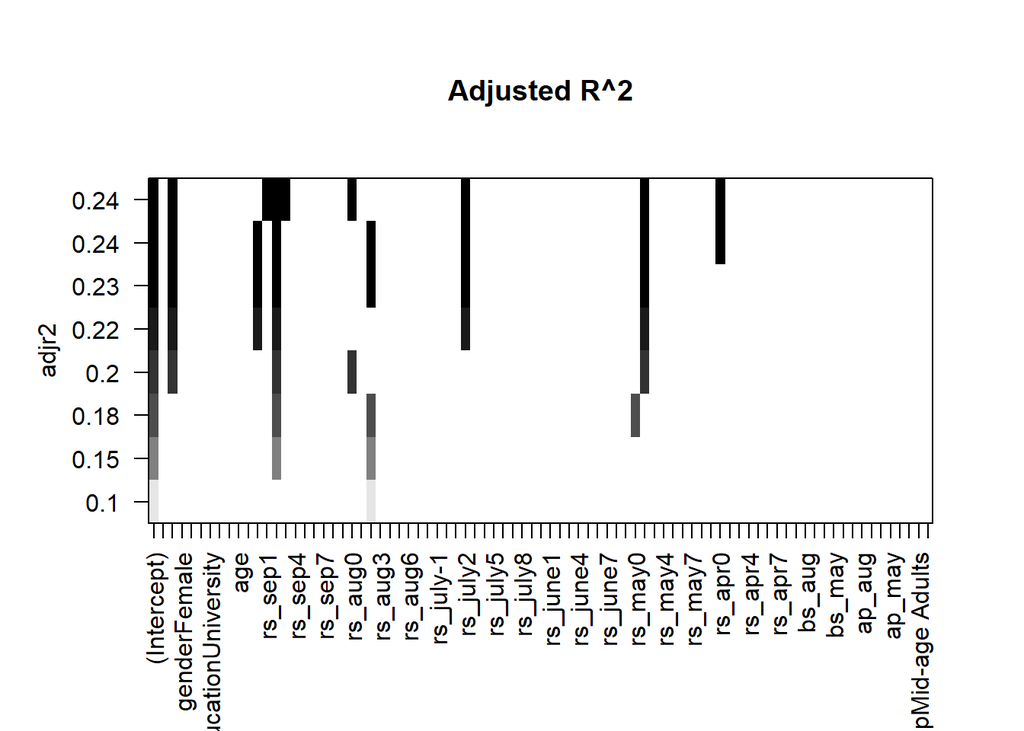

```r
library("leaps")
data.renamed <- data
cnames <- colnames(data.renamed)
cnames[which(cnames == 'default_r')] <- 'y'
colnames(data.renamed) <- cnames
reg.leaps <- regsubsets(y~., data = data.renamed, nbest = 1, method = "exhaustive", really.big = T)  # leaps,
plot(reg.leaps, scale = "adjr2", main = "Adjusted R^2")
```

I wish not to select features based on the regsubsets plot as I strongly believe it misses out on many important variables that play critical role in predicting whether a person would default on his/her next month bill.

```r
get_cm <- function(predictions, model, co, g_truth)
{
  # pred.list <- round(predictions) # for now
  pred.list <- predictions
  pred.list[predictions <= co] <- 1
  pred.list[predictions > co] <- 2
  cm <- table(pred.list, g_truth)
return(cm)
}

get_evalmetrics <- function(cm, model, n_preds)
{
  precision <- cm[1, 1]/(cm[1, 1] + cm[1, 2])
  recall <- cm[1, 1]/(cm[1, 1] + cm[2, 1])
  sensitivity <- recall
  specificity <- cm[2, 2]/(cm[2, 2] + cm[1, 2])
  f1 <- 2 * ((precision * recall)/(precision + recall))
  mcfadden <- 1 - model$deviance/model$null.deviance
  accuracy <- (cm[1, 1] + cm[2, 2])/n_preds
  metrics <- c(precision, recall, sensitivity, specificity, f1, mcfadden, accuracy)

  return(metrics)
}
```

```r
co_values <- seq(0.1, 0.9, length=50)
eval_df <- data.frame(matrix(0, nrow=length(co_values), ncol=8))
colnames(eval_df) <- c('Cutoff', 'Precision', 'Recall', 'Sensitivity', 'Specificity', 'F1', 'McFadden', 'Accuracy')
fm.y_prob <- predict.glm(full_model, newdata=data, type=c("response"))

# Collect metrics for all cutoff values
for(i in 1:length(co_values))
{
  co <- co_values[i]
  tmp_cm <- get_cm(fm.y_prob, full_model, co, data$default_r)
  tmp_metrics <- get_evalmetrics(tmp_cm, full_model, length(fm.y_prob))
  eval_df[i,] <- c(co, tmp_metrics)
}
# colnames(tmp_cm) <- c('Act.Pos', 'Act.Neg')
# tmp_metrics
# eval_df
```

```r
exp_coeff <- exp(full_model$coefficients)
exp_coeff
```

```
##              (Intercept)             credit_limit             genderFemale
##                 3.15e-01                 1.00e+00                 7.08e-01
##     educationHigh School educationGraduate School      educationUniversity
##                 3.60e+00                 3.00e+00                 2.97e+00
##           maritalMarried            maritalOthers                      age
##                 1.20e+00                 1.91e+00                 1.00e+00
##                 rs_sep-1                  rs_sep0                  rs_sep1
##                 1.55e+00                 9.81e-01                 1.86e+00
##                  rs_sep2                  rs_sep3                  rs_sep4
##                 6.12e+00                 5.60e+00                 4.68e+00
##                  rs_sep5                  rs_sep6                  rs_sep7
##                 3.94e+00                 8.92e-01                 1.49e+01
##                  rs_sep8                 rs_aug-1                  rs_aug0
##                 3.00e+00                 8.55e-01                 7.01e-01
##                  rs_aug1                  rs_aug2                  rs_aug3
##                 8.48e-01                 1.43e+00                 1.76e+00
##                  rs_aug4                  rs_aug5                  rs_aug6
##                 8.34e-01                 1.25e+00                 1.09e+01
##                  rs_aug7                  rs_aug8                rs_july-1
##                 2.43e+00                 5.85e-07                 9.58e-01
##                 rs_july0                 rs_july1                 rs_july2
##                 9.34e-01                 3.95e+00                 1.60e+00
##                 rs_july3                 rs_july4                 rs_july5
##                 1.54e+00                 1.06e+00                 6.87e-01
##                 rs_july6                 rs_july7                 rs_july8
##                 3.10e+00                 3.77e+00                 1.25e-01
##                rs_june-1                 rs_june0                 rs_june1
##                 8.64e-01                 8.61e-01                 1.17e+00
##                 rs_june2                 rs_june3                 rs_june4
##                 1.54e+00                 2.26e+00                 3.37e+00
##                 rs_june5                 rs_june6                 rs_june7
##                 9.75e-01                 8.96e-01                 3.48e+00
##                 rs_june8                 rs_may-1                  rs_may0
##                 4.32e-01                 8.50e-01                 8.04e-01
##                  rs_may2                  rs_may3                  rs_may4
##                 1.55e+00                 1.52e+00                 1.47e+00
##                  rs_may5                  rs_may6                  rs_may7
##                 8.03e-01                 9.33e-01                 2.28e+00
##                  rs_may8                 rs_apr-1                  rs_apr0
##                 1.49e+01                 9.47e-01                 7.17e-01
##                  rs_apr2                  rs_apr3                  rs_apr4
##                 1.50e+00                 2.14e+00                 1.16e+00
##                  rs_apr5                  rs_apr6                  rs_apr7
##                 4.85e+00                 1.63e+00                 3.56e+00
##                  rs_apr8                   bs_sep                   bs_aug
##                 4.71e+04                 1.00e+00                 1.00e+00
##                  bs_july                  bs_june                   bs_may
##                 1.00e+00                 1.00e+00                 1.00e+00
##                   bs_apr                   ap_sep                   ap_aug
##                 1.00e+00                 1.00e+00                 1.00e+00
##                  ap_july                  ap_june                   ap_may
##                 1.00e+00                 1.00e+00                 1.00e+00
##                   ap_apr
##                 1.00e+00
```

**Interpretation on exponentiated coefficients**

Wish to include only those that affect the default rate substantially. Here coefficients above 1 represents the factor by which odds-ratio is increased (defaulting to non-defaulting) as the unit of the variable increases.

Intercept - The intercept value 0.315 means a person is less likely to default on average.

credit_limit - The odds-ratio of defaulting to not-defaulting decreases by a factor of 1 for one unit of increase in credit limit. From this it can be inferred that people who typically default have lesser credit limit.

genderFemale - The odds-ratio of defaulting to not-defaulting decreases by a factor of 0.708 when the applicant is female.

educationHigh School - The odds-ratio (defaulting to not defaulting) increases by a factor of 3.603 when the applicant holds a High School qualification and the chances are substantial compared to those with other qualifications.

age - For every increase in the unit, the odds ratio improve by a factor of 1.003.

Commenting on the repayment status coefficient. Compared to all months, defaulting on `September` month appears to increase the odds-ratio by a factor of 1.549.

Regarding the gender and education, I believe some of the visual plots and initial conclusions made in the EDA were skewed by the SMOTE process.

Commenting on the amount paid coefficients. I normally do not average coefficients as it is generally considered an incorrect pracise. However, `ap` coefficients are almost same with slight variation. Hence in order to make a conclusion, I wish to average to mention by what factor on average paying bills every month affect the odds-ratio. The odds-ratio decreases on average by a factor of 1 by paying bills monthly.

**Conclusions and revisions to SMART questions from Logit model**

1. High School qualification holders have higher chances of making default on credit card bill. My understanding would be, even those with better qualification struggle to find a good job in Taiwan.
2. Contrary to our findings from EDA, females are less likely than males to default on their credit card bill.
3. Increase in age means more chances of defaulting. Conforming to my previous hypothesis, it is my understanding from the results that there is a job crisis in Taiwan that may be a latent factor. (China News)[https://www.taiwannews.com.tw/en/news/339690]
4. Yes, being married improves the chances of defaulting and it makes sense. Having said there is a job crisis, and perhaps an unreliable source of income, these factors lead to default on their bill.

Overall, my understanding from the EDA and the results conveyed by the Logit model is that the cause for all financial crisis in the country was caused by inadequate job openings to match the ever growing population. In order to reduce the financial risk of the banks, and to restore the overall financial health of the country, it would be imperative to equal job opportunities for both Men and Women, and offer better education that I hope will improve the situation.

### 4.2.2 Data Partitioning

Here I wish to retain $80\%$ of the data for training since $20\%$ from the $80\%$ of training data will be taken for validation.

```r
library(caret)
set.seed(123)
trainIndex <- createDataPartition(data$default_r, p=.8,
                                  list = FALSE,
                                  times = 1)
train_set <- data[trainIndex,]
test_set <- data[-trainIndex,]

print('Training set:')
```

```
## [1] "Training set:"
```

```r
table(train_set$default_r)
```

```
##
##    No   Yes
## 21220 15915
```

```r
print('Testing set:')
```

```
## [1] "Testing set:"
```

```r
summary(test_set$default_r, main='Testing set')
```

```
##   No  Yes
## 5304 3978
```

The proportion of Default and Non-default size is the same between training and the test set.

Training yes - 0.429  
Testing yes - 0.429

### 4.2.3 GLM Second Attempt with training set

```r
full_model <- glm('default_r~.-id-age_group', data=train_set, family='binomial')
```

Confusion Matrix on training set

```r
tr_pred <- full_model$fitted.values
tr_pred <- ifelse(tr_pred > 0.37, 'Yes', 'No') # I got this value after the following steps
tr_pred <- factor(tr_pred)
confusionMatrix(tr_pred, reference = train_set$default_r)
```

```
## Confusion Matrix and Statistics
##
##           Reference
## Prediction    No   Yes
##        No  15960  3612
##        Yes  5260 12303
##
##                Accuracy : 0.761
##                  95% CI : (0.757, 0.765)
##     No Information Rate : 0.571
##     P-Value [Acc > NIR] : <2e-16
##
##                   Kappa : 0.518
##
##  Mcnemar's Test P-Value : <2e-16
##
##             Sensitivity : 0.752
##             Specificity : 0.773
##          Pos Pred Value : 0.815
##          Neg Pred Value : 0.701
##              Prevalence : 0.571
##          Detection Rate : 0.430
##    Detection Prevalence : 0.527
##       Balanced Accuracy : 0.763
##
##        'Positive' Class : No
##
```

#### 4.2.3.1 Evaluation on test set

```r
get_risky_amt <- function(cm, t_data)
{
  FN <- cm[1, 2]
  # Exactly picking those mislcassified observations
  # and doing an average is not probably a good idea since
  # depending on the subset (in k-fold) the there will be variation in prediction.
  # Hence an average balance from a sample of misclassification size
  # would be adequate
  test_subset_indices <- sample(nrow(t_data), FN, replace=F)
  test_subset <- t_data[test_subset_indices,]
  total_bill <- colSums(test_subset[, 13:18]) # bs for all months
  total_paid <- colSums(test_subset[, 19:24]) # ap for all months
  avg_due_person <- sum(total_bill - total_paid) # average due per person
  return(avg_due_person)
}
```

```r
co_values <- seq(0.1, 0.9, length=50)
eval_df <- data.frame(matrix(0, nrow=length(co_values), ncol=9))
colnames(eval_df) <- c('Cutoff', 'Precision', 'Recall', 'Sensitivity', 'Specificity', 'F1', 'McFadden', 'Accuracy', 'Risk')
fm.y_prob <- predict.glm(full_model, newdata=test_set, type=c("response"))

# Collect metrics for all cutoff values
for(i in 1:length(co_values))
{
  co <- co_values[i]
  tmp_cm <- get_cm(fm.y_prob, full_model, co, test_set$default_r)
  risky_amt <- get_risky_amt(tmp_cm, test_set)
  tmp_metrics <- get_evalmetrics(tmp_cm, full_model, length(fm.y_prob))
  eval_df[i,] <- c(c(co, tmp_metrics), risky_amt)
}
# colnames(tmp_cm) <- c('Act.Pos', 'Act.Neg')
# tmp_metrics
# eval_df
```

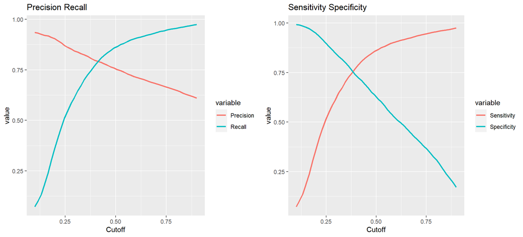

```r
library(reshape2)
prec_recall.molten <- melt(eval_df[, c("Cutoff", "Precision", "Recall")], id=c("Cutoff"))
sens_spec.molten <- melt(eval_df[, c("Cutoff", "Sensitivity", "Specificity")], id=c("Cutoff"))

prec_recall.plot <- ggplot(prec_recall.molten, aes(x=Cutoff, y=value, color=variable )) +
                    geom_line(lwd=1) +
                    ggtitle('Precision Recall')
sens_spec.plot <- ggplot(sens_spec.molten, aes(x=Cutoff, y=value, color=variable)) +
                  geom_line(lwd=1) +
                    ggtitle('Sensitivity Specificity')

grid.arrange(prec_recall.plot, sens_spec.plot, nrow=1)
```

The above results are for the test set and it is better compared to KNN.

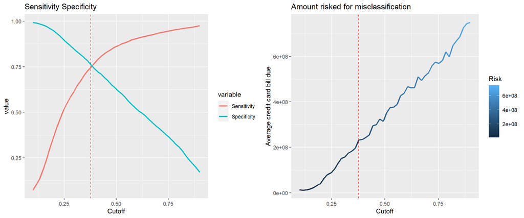

```r
risk_plot <- ggplot(eval_df, aes(x=Cutoff, y=Risk, color=Risk)) +
             geom_line(lwd=1) +
             geom_vline(xintercept=0.3775510, color='red', linetype='dashed') +
             ylab('Average credit card bill due') +
             ggtitle('Amount risked for misclassification')

grid.arrange(sens_spec.plot +
               geom_vline(xintercept=0.3775510, color='red', linetype='dashed'),
             risk_plot, nrow=1)
```

The dashed vertical in red color represents the optimal cutoff threshold.

**Confusion matrix** for the cutoff value that shows intersecting Sensitivity and Specificity would be:

```r
tmp_cm <- get_cm(fm.y_prob, full_model, 0.3775510, test_set$default_r) # cutoff value = 0.3775510
# row.names(tmp_cm) <- c("Pred No", "Pred Yes")
# colnames(tmp_cm) <- c("Actual No", "Actual Yes")
tmp_cm
```

```
##          g_truth
## pred.list   No  Yes
##         1 3958  944
##         2 1346 3034
```

```r
tmp_metrics <- data.frame(matrix(0, nrow=1, ncol=7))
colnames(tmp_metrics) <- c('Precision', 'Recall', 'Sensitivity', 'Specificity', 'F1', 'McFadden', 'Accuracy')
tmp_metrics[1,] <- get_evalmetrics(tmp_cm, full_model, length(fm.y_prob))
# tmp_metrics
```

**Performance Metrics** at optimal cut-off threshold.

```r
rmarkdown::paged_table(data.frame(t(tmp_metrics)))
```

|  | t.tmp_metrics. |
| --- | --- |
| Precision | 0.807 |
| Recall | 0.746 |
| Sensitivity | 0.746 |
| Specificity | 0.763 |
| F1 | 0.776 |
| McFadden | 0.248 |
| Accuracy | 0.753 |

**ROC Curve and AUC**

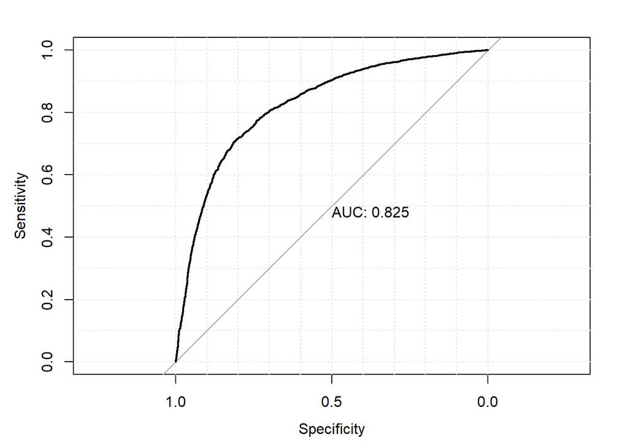

```r
library(pROC)

roc(test_set$default_r, fm.y_prob,
            smoothed = TRUE,
            plot=TRUE, grid=TRUE,
            print.auc=TRUE, show.thres=TRUE)
```

For this model, $0.3775510$ would be the optimal cut-off value since it gives a good balance between both Sensitivity and Specificity. A question may naturally come in mind why not select a slightly lower cut-off value that would result in even better Specificity (recall of defaulter class). The answer to that is, although it may result in better default prediction, it may also result in losing potential clients by classifying those who would not default as high chance of defaulting. This means, such a mis-classification may lead to reduced credit limit assigned to potential clients that may make them explore other banks. Hence, a good balance of Sensitivity and Specificity at approximately 75% accuracy appears a good fit. Also the AUC is above the mark.

**Residual plot**

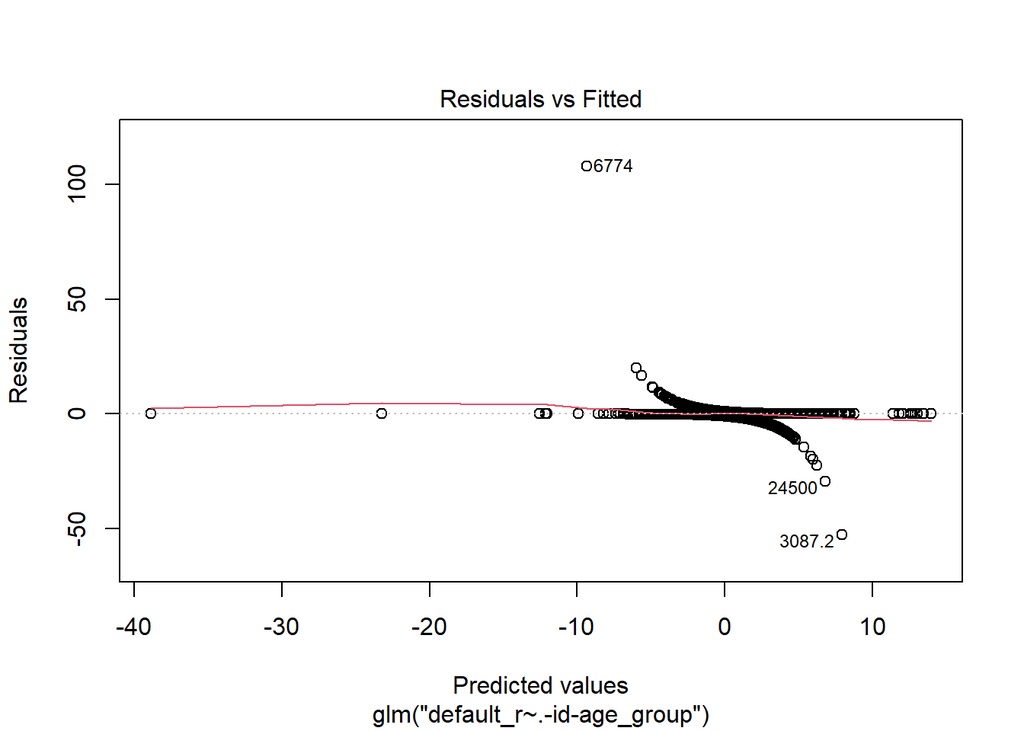

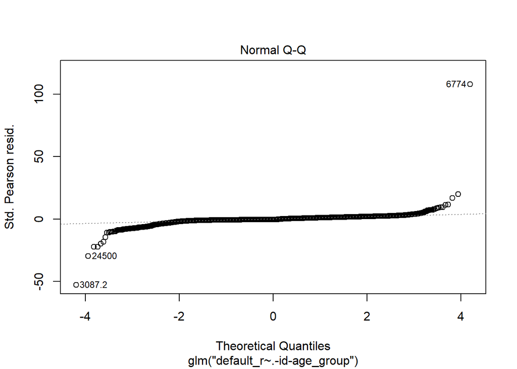

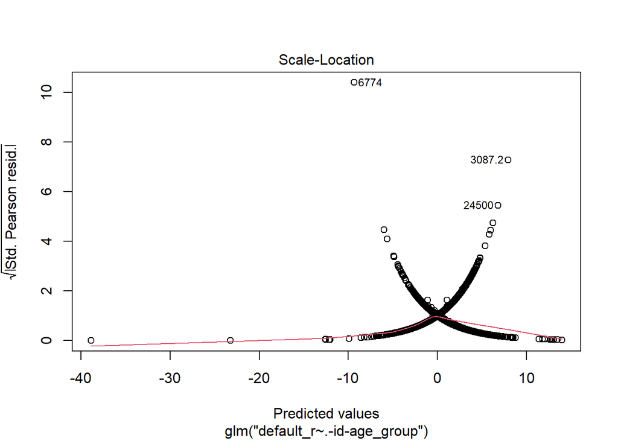

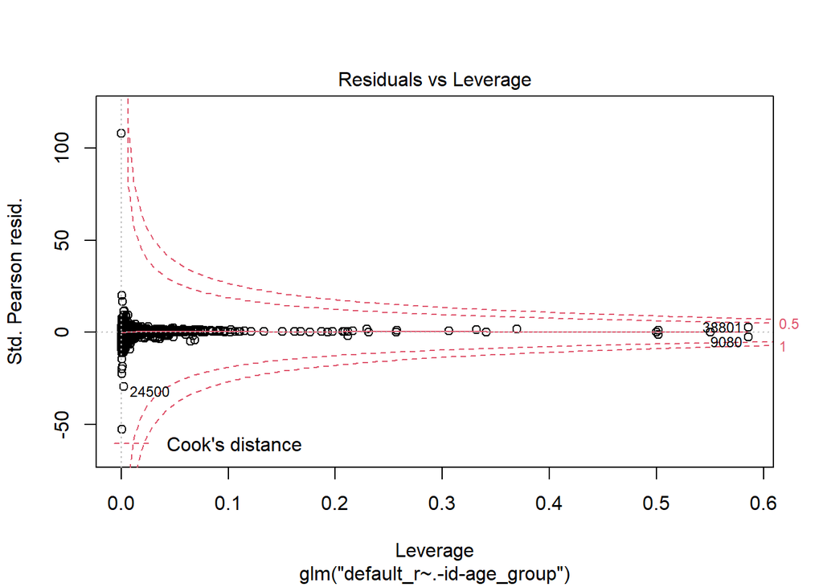

```r
plot(full_model)
```

Chi-square on null deviance: 0  
Chi-square on residual deviance: 3.293^{-5}

Both the pvalues were below the significant threshold that says the model is not a good fit.

#### 4.2.3.2 Conclusions from predictions

A sample is taken from the test set (non-defaulter) and let’s first make a prediction so that we can make comparison with the result when we would change the data.

```r
# I am doing head here since they will transfer the factor level information
newdata <- head(test_set[test_set$default_r=='No',], 1)
newdata$gender <- 'Male'
newdata$education <- 'High School'
newdata$marital <- 'Single'
newdata$age <- 23
newdata[1, seq(13, 18, length=6)] <- colMeans(test_set[test_set$default_r=='No', seq(13, 18, length=6)])
newdata[1, 19:24] <- colMeans(test_set[test_set$default_r=='No', 19:24])
hyp_res <- predict.glm(full_model, newdata, type='response')
hyp_res
```

```
## 22017
## 0.368
```

Now I wish to change the repayment status to 2 months due for september and assess how repayment status affect the chances of defaulting.

```r
newdata2 <- newdata
newdata2$rs_sep <- factor(2)
hyp_res <- predict.glm(full_model, newdata2, type='response')
hyp_res
```

```
## 22017
## 0.786
```

Using the original data point that we sampled from the test set, this time I wish to change the gender to Female to observe the change in probability value.

```r
newdata3 <- newdata
newdata$gener <- 'Female'
hyp_res <- predict.glm(full_model, newdata3, type='response')
hyp_res
```

```
## 22017
## 0.368
```

Again, I wish to change the qualification to University from High School to observe the changes in possibility of defaulting.

```r
newdata4 <- newdata
newdata4$age <- 34
newdata4$education <- 'University'
hyp_res <- predict.glm(full_model, newdata4, type='response')
hyp_res
```

```
## 22017
## 0.332
```

Clearly the probability has went down this time. It is high school qualification holders who are more likely to default than University level qualification holders.

### 4.2.4 KNN on scaled data

```r
library(doParallel)

data2 <- data
data2 <- data2[, c(-1, -26)] # id, age_group
data2$rs_sep <- ifelse(as.numeric(as.character(data$rs_sep)) >= 1, 'Due', 'Good')
data2$rs_aug <- ifelse(as.numeric(as.character(data$rs_aug)) >= 1, 'Due', 'Good')
data2$rs_july <- ifelse(as.numeric(as.character(data$rs_july)) >= 1, 'Due', 'Good')
data2$rs_june <- ifelse(as.numeric(as.character(data$rs_june)) >= 1, 'Due', 'Good')
data2$rs_may <- ifelse(as.numeric(as.character(data$rs_may)) >= 1, 'Due', 'Good')
data2$rs_apr <- ifelse(as.numeric(as.character(data$rs_apr)) >= 1, 'Due', 'Good')

data2$rs_sep <- factor(data2$rs_sep)
data2$rs_aug <- factor(data2$rs_aug)
data2$rs_july <- factor(data2$rs_july)
data2$rs_june <- factor(data2$rs_june)
data2$rs_may <- factor(data2$rs_may)
data2$rs_apr <- factor(data2$rs_apr)

#---------- Cross validation

# define training control

trainIndx <- createDataPartition(data2$default_r, p=0.8, list=F)
train_set <- data2[trainIndx,]
test_set <- data2[-trainIndx,]

library(ezids)
train_set <- uzscale(train_set)
test_set <- uzscale(test_set)

cl <- makePSOCKcluster(8)
registerDoParallel(cl)
train_control <- trainControl(method = "cv", number = 5, allowParallel=T)

# train the model on training set
knnModel <- train(default_r ~.,
               data = train_set,
               trControl = train_control,
               method = "knn",
               metric='Accuracy', tuneLength=20)
stopCluster(cl)
# print cv scores
knnModel
```

```
## k-Nearest Neighbors
##
## 37135 samples
##    23 predictor
##     2 classes: 'No', 'Yes'
##
## No pre-processing
## Resampling: Cross-Validated (5 fold)
## Summary of sample sizes: 29708, 29708, 29708, 29708, 29708
## Resampling results across tuning parameters:
##
##   k   Accuracy  Kappa
##    5  0.760     0.500
##    7  0.761     0.501
##    9  0.763     0.506
##   11  0.764     0.507
##   13  0.764     0.507
##   15  0.765     0.509
##   17  0.764     0.505
##   19  0.764     0.505
##   21  0.763     0.502
##   23  0.763     0.502
##   25  0.763     0.502
##   27  0.763     0.502
##   29  0.762     0.500
##   31  0.762     0.500
##   33  0.762     0.499
##   35  0.761     0.497
##   37  0.761     0.497
##   39  0.761     0.498
##   41  0.761     0.497
##   43  0.760     0.495
##
## Accuracy was used to select the optimal model using the largest value.
## The final value used for the model was k = 15.
```

#### 4.2.4.1 Evaluate KNN on Test set

```r
knn_pred <- predict(knnModel, newdata=test_set)
confusionMatrix(knn_pred, reference=test_set$default_r)
```

```
## Confusion Matrix and Statistics
##
##           Reference
## Prediction   No  Yes
##        No  4576 1472
##        Yes  728 2506
##
##                Accuracy : 0.763
##                  95% CI : (0.754, 0.772)
##     No Information Rate : 0.571
##     P-Value [Acc > NIR] : <2e-16
##
##                   Kappa : 0.505
##
##  Mcnemar's Test P-Value : <2e-16
##
##             Sensitivity : 0.863
##             Specificity : 0.630
##          Pos Pred Value : 0.757
##          Neg Pred Value : 0.775
##              Prevalence : 0.571
##          Detection Rate : 0.493
##    Detection Prevalence : 0.652
##       Balanced Accuracy : 0.746
##
##        'Positive' Class : No
##
```

The cross validation on KNN does show decent amount of accuracy. However the Specificity is not adequate enough in comparison with what we got from the Logit model. Hence, I wish not to proceed further in this direction.

### 4.2.5 Decision Tree

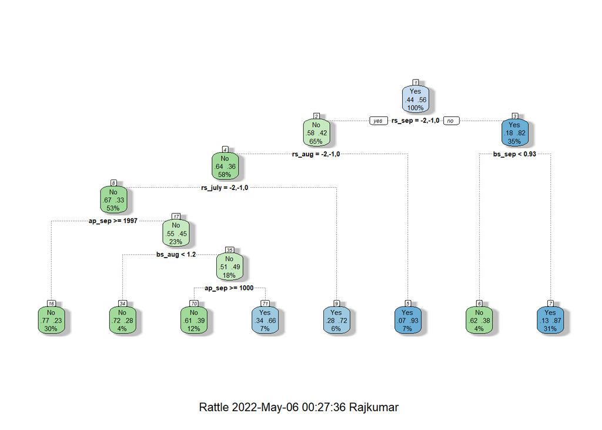

```r
library(rpart)
library(rpart.plot)
library(rattle)

trainIdx <- createDataPartition(data$default_r, p=0.8, list=F)
train_set <- data[trainIdx,]
test_set <- data[-trainIdx,]

tree_cnames <- colnames(train_set)[is.na(pmatch(colnames(train_set), c("id", "age_group")))]

weights <- rep(0, nrow(train_set))
weights[train_set$default_r=='Yes'] <- 0.63
weights[train_set$default_r=='No'] <- 0.37

# weights <- ifelse(train_set$default_r == 'No', negativeWeight, positiveWeight)

dt_fit <- rpart(default_r~., data=train_set[, tree_cnames], method="class", weights=weights)
fancyRpartPlot(dt_fit)
```

If you would download or open the above Decision Tree image in a new tab, you will see the rules are very intuitive. However the quality of the image itself is very bad. Hence I will use `rpart.plot` to get the rules from the Decision Tree.

```r
rmarkdown::paged_table(rpart.rules(dt_fit, cover=T))
```

|  | default_r |  |  |  |  |  |  |  |  |  |  |  |  |  |  |  |  |  |  |  |  |  |  |  |  |  |  | cover |
| --- | --- | --- | --- | --- | --- | --- | --- | --- | --- | --- | --- | --- | --- | --- | --- | --- | --- | --- | --- | --- | --- | --- | --- | --- | --- | --- | --- | --- |
| 16 | 0.23 | when | rs_sep | is | -2 or -1 or 0 | & | rs_aug | is | -2 or -1 or 0 | & | rs_july | is | -2 or -1 or 0 | & | ap_sep | >= |  |  | 1997 |  |  |  |  |  |  |  |  | 30% |
| 34 | 0.28 | when | rs_sep | is | -2 or -1 or 0 | & | rs_aug | is | -2 or -1 or 0 | & | rs_july | is | -2 or -1 or 0 | & | ap_sep | < | 1997 |  |  | & | bs_aug | < | 1.2 |  |  |  |  | 4% |
| 6 | 0.38 | when | rs_sep | is | 1 or 2 or 3 or 4 or 5 or 6 or 7 or 8 |  |  |  |  |  |  |  |  |  |  |  |  |  |  |  |  |  |  | & | bs_sep | < | 0.93 | 4% |
| 70 | 0.39 | when | rs_sep | is | -2 or -1 or 0 | & | rs_aug | is | -2 or -1 or 0 | & | rs_july | is | -2 or -1 or 0 | & | ap_sep | is | 1000 | to | 1997 | & | bs_aug | >= | 1.2 |  |  |  |  | 12% |
| 71 | 0.66 | when | rs_sep | is | -2 or -1 or 0 | & | rs_aug | is | -2 or -1 or 0 | & | rs_july | is | -2 or -1 or 0 | & | ap_sep | < | 1000 |  |  | & | bs_aug | >= | 1.2 |  |  |  |  | 7% |
| 9 | 0.72 | when | rs_sep | is | -2 or -1 or 0 | & | rs_aug | is | -2 or -1 or 0 | & | rs_july | is | 2 or 3 or 4 or 5 or 6 or 7 or 8 |  |  |  |  |  |  |  |  |  |  |  |  |  |  | 6% |
| 7 | 0.87 | when | rs_sep | is | 1 or 2 or 3 or 4 or 5 or 6 or 7 or 8 |  |  |  |  |  |  |  |  |  |  |  |  |  |  |  |  |  |  | & | bs_sep | >= | 0.93 | 31% |
| 5 | 0.93 | when | rs_sep | is | -2 or -1 or 0 | & | rs_aug | is | 1 or 2 or 3 or 4 or 5 or 6 or 7 |  |  |  |  |  |  |  |  |  |  |  |  |  |  |  |  |  |  | 7% |

**Importance of variables**

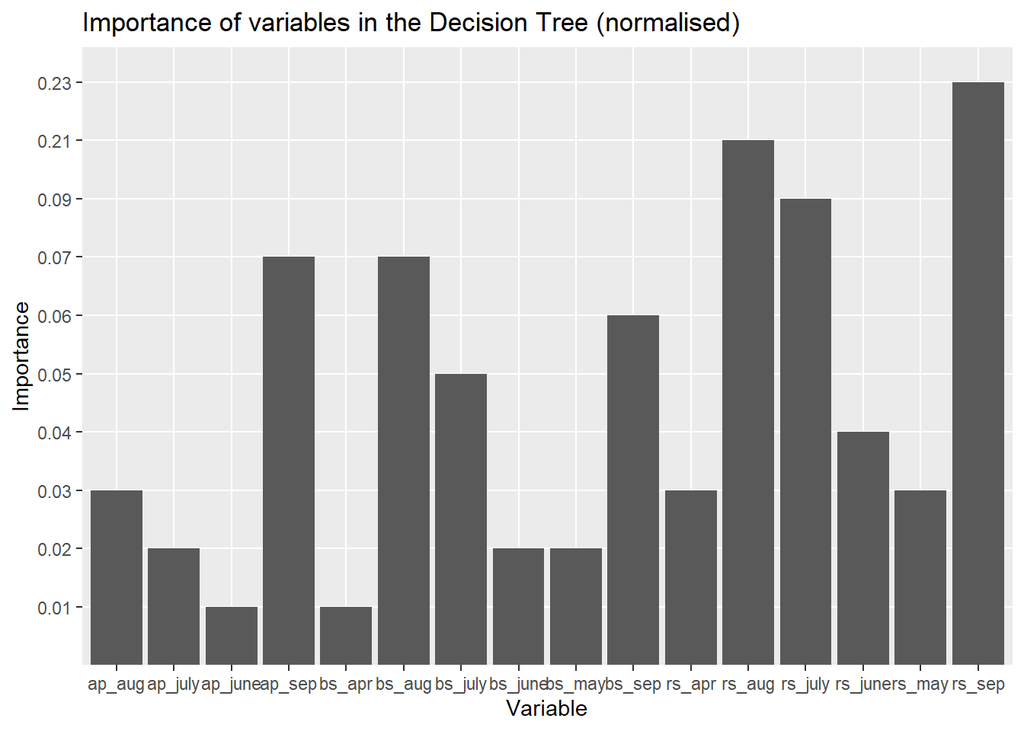

```r
var_importance <- dt_fit$variable.importance
var_importance <- round(var_importance/sum(var_importance), 2)
var_importance <- data.frame(var_importance)
importance <- var_importance$var_importance
var_names <- row.names(var_importance)
var_importance <- cbind(var_names, importance)
var_importance <- data.frame(var_importance)
colnames(var_importance) <- c("Variable", "Importance")
ggplot(var_importance, aes(x=Variable, y=Importance)) +
geom_bar(stat='identity', position='identity') +
  ggtitle('Importance of variables in the Decision Tree (normalised)')
```

Now if you recall what I mentioned in the feature selection section and contrast this plot with that, my decision would make sense.

**Confusion Matrix**

```r
dt_cm = confusionMatrix( predict(dt_fit, newdata=test_set[, tree_cnames], type = "class"), reference = test_set$default_r )
print('Overall: ')
```

```
## [1] "Overall: "
```

```r
dt_cm$overall
```

```
##       Accuracy          Kappa  AccuracyLower  AccuracyUpper   AccuracyNull
##          0.785          0.560          0.776          0.793          0.571
## AccuracyPValue  McnemarPValue
##          0.000          0.408
```

```r
rmarkdown::paged_table(data.frame(dt_cm$byClass))
```

|  | dt_cm.byClass |
| --- | --- |
| Sensitivity | 0.815 |
| Specificity | 0.744 |
| Pos Pred Value | 0.810 |
| Neg Pred Value | 0.752 |
| Precision | 0.810 |
| Recall | 0.815 |
| F1 | 0.813 |
| Prevalence | 0.571 |
| Detection Rate | 0.466 |
| Detection Prevalence | 0.576 |

[output cut: 1 more lines]

```r
dt_cm
```

```
## Confusion Matrix and Statistics
##
##           Reference
## Prediction   No  Yes
##        No  4325 1017
##        Yes  979 2961
##
##                Accuracy : 0.785
##                  95% CI : (0.776, 0.793)
##     No Information Rate : 0.571
##     P-Value [Acc > NIR] : <2e-16
##
##                   Kappa : 0.56
##
##  Mcnemar's Test P-Value : 0.408
##
##             Sensitivity : 0.815
##             Specificity : 0.744
##          Pos Pred Value : 0.810
##          Neg Pred Value : 0.752
##              Prevalence : 0.571
##          Detection Rate : 0.466
##    Detection Prevalence : 0.576
##       Balanced Accuracy : 0.780
##
##        'Positive' Class : No
##
```

This is not a clear plot.

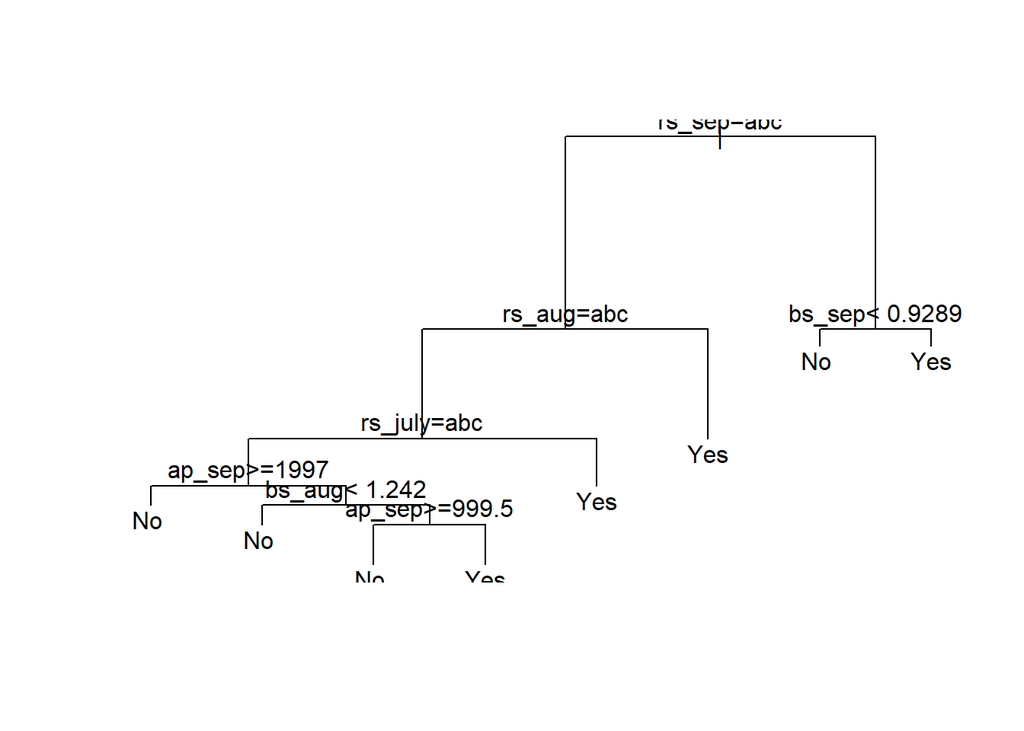

```r
plot(dt_fit)
text(dt_fit)
```

### 4.2.6 Ada Boost

This will take some time to run.

```r
# renamed to train_set2 so when you rerun it does not mess up
# train_set2 <- train_set[, c(-1, -26)] # id, age_group
# test_set2 <- test_set[, c(-1, -26)]
#
# # adaboost_ctrl <- trainControl(method='oob', number=5)
#
# # train the model on training set
# ab_fit <- train(default_r ~.,
#                  data = train_set2,
#                  # trControl = adaboost_ctrl,
#                  method = "adaboost",
#                  metric='Accuracy')
```

Adaboost appears to take over 2 hours to train and due to time constraints, I wish not to proceed further with this model.

### 4.2.7 Random Forest

```r
library(randomForest)

train_lbls <- train_set$default_r
train_set3 <- train_set[, c(-1, -25, -26)] # id, default_r, age_group
test_lbls <- test_set$default_r
test_set3 <- test_set[, c(-1, -25, -26)]

rfFit <- randomForest(x=train_set3, y=train_lbls, importance=T)
rfFit
```

```
##
## Call:
##  randomForest(x = train_set3, y = train_lbls, importance = T)
##                Type of random forest: classification
##                      Number of trees: 500
## No. of variables tried at each split: 4
##
##         OOB estimate of  error rate: 10.7%
## Confusion matrix:
##        No   Yes class.error
## No  20197  1023      0.0482
## Yes  2940 12975      0.1847
```

```r
rf_pred <- predict(rfFit, test_set)
confusionMatrix(rf_pred, reference=test_lbls)
```

```
## Confusion Matrix and Statistics
##
##           Reference
## Prediction   No  Yes
##        No  5070  741
##        Yes  234 3237
##
##                Accuracy : 0.895
##                  95% CI : (0.889, 0.901)
##     No Information Rate : 0.571
##     P-Value [Acc > NIR] : <2e-16
##
##                   Kappa : 0.782
##
##  Mcnemar's Test P-Value : <2e-16
##
##             Sensitivity : 0.956
##             Specificity : 0.814
##          Pos Pred Value : 0.872
##          Neg Pred Value : 0.933
##              Prevalence : 0.571
##          Detection Rate : 0.546
##    Detection Prevalence : 0.626
##       Balanced Accuracy : 0.885
##
##        'Positive' Class : No
##
```

Try changing the class weights

```r
weights <- train_lbls
weights <- ifelse(train_lbls=='Yes', 0.7, 0.3)
rfFit2 <- randomForest(x=train_set3, y=train_lbls, importance=T, weights=weights)
```

**Confusion Matrix** on Train set

```r
rf_pred2_tr <- predict(rfFit2, train_set3)
confusionMatrix(rf_pred2_tr, reference=train_lbls)
```

```
## Confusion Matrix and Statistics
##
##           Reference
## Prediction    No   Yes
##        No  21046    25
##        Yes   174 15890
##
##                Accuracy : 0.995
##                  95% CI : (0.994, 0.995)
##     No Information Rate : 0.571
##     P-Value [Acc > NIR] : <2e-16
##
##                   Kappa : 0.989
##
##  Mcnemar's Test P-Value : <2e-16
##
##             Sensitivity : 0.992
##             Specificity : 0.998
##          Pos Pred Value : 0.999
##          Neg Pred Value : 0.989
##              Prevalence : 0.571
##          Detection Rate : 0.567
##    Detection Prevalence : 0.567
##       Balanced Accuracy : 0.995
##
##        'Positive' Class : No
##
```

**Confusion Matrix** on Test set

```r
rf_pred2_ts <- predict(rfFit2, test_set)
confusionMatrix(rf_pred2_ts, reference=test_lbls)
```

```
## Confusion Matrix and Statistics
##
##           Reference
## Prediction   No  Yes
##        No  4912  600
##        Yes  392 3378
##
##                Accuracy : 0.893
##                  95% CI : (0.887, 0.899)
##     No Information Rate : 0.571
##     P-Value [Acc > NIR] : < 2e-16
##
##                   Kappa : 0.78
##
##  Mcnemar's Test P-Value : 4.96e-11
##
##             Sensitivity : 0.926
##             Specificity : 0.849
##          Pos Pred Value : 0.891
##          Neg Pred Value : 0.896
##              Prevalence : 0.571
##          Detection Rate : 0.529
##    Detection Prevalence : 0.594
##       Balanced Accuracy : 0.888
##
##        'Positive' Class : No
##
```

The random forest after adjusting the class weights gives slightly better results, and due to time constraints I wish to end my research here. The adaboost code is in the Rmd file and it appears to take over 2 hours to complete. It is not feasible to re-run for every single change we make to adaboost code. Hence I have decided to comment it.

# 5 References

1. Wang, E. (2006). The Taiwan Credit Card Crisis - Financial Ethics. Sevenpillarsinstitute.org. Retrieved May 1, 2022, from https://sevenpillarsinstitute.org/case-studies/taiwans-credit-card-crisis/
2. Eberle, W., Islam, S. R., & Ghafoor, S. K. (2018, July 2). Credit Default Mining Using Combined Machine Learning and Heuristic Approach. Retrieved May 1, 2022, from https://arxiv.org/ftp/arxiv/papers/1807/1807.01176.pdf
3. France-Presse, A. (2006, December 8). Job shortage predicted in China: Taiwan news: 2006-12-09 00:00:00. Taiwan News. Retrieved May 1, 2022, from https://www.taiwannews.com.tw/en/news/339690